# 36-315 Homework 1, Fall 2021

SOLUTIONS

Due Tuesday, Sept. 7, 2021 (11:59pm ET) on Gradescope

## Introduction to `R`, RStudio, Data Types, and Critiquing Graphics

# Problem 1: Critiquing Graphs (15 points)

As part of your course grade for 36-315, you must post on Piazza once a month describing a graph you found online (see syllabus for details). In this question, you will get practice doing this, so that expectations for these once-a-month Piazza posts are clear. Note that the following is for homework credit, NOT once-a-month Piazza credit; you CANNOT use the graphic you discuss here for your once-a-month Piazza post.

1. (5 points) Find a graph from the Internet from the last 7 days (e.g., from a news article, blog post, online forum, etc.) or from an academic journal from the last 60 days. For this part, all you have to do is include the graph. You have two choices here:
- embed the graph/image directly in RMarkdown (see below for instructions), or
- include a link to the graph in your answer to this question.

*[Here](https://i.redd.it/erdv3yn78d941.png) is a link to the graph. This is from reddit.com’s /r/dataisbeautiful subreddit. Following the theme of working with the Titanic data, the graph is about Leonardo DiCaprio (who starred in the Titanic movie).*

2. (5 points) **Describe the graph** in 2-5 sentences. Be sure that your description touches on the following points:
- What does the graph show?
- What variables are plotted, whether it’s via symbols, color, or other features of the graph?
- What is the main result of the graph?

*The graph focuses on two variables: DiCaprio’s age over time and his partner’s (girlfriend’s) age over time. DiCaprio’s age is in yellow, and as the graph affirms, “Yup, he ages linearly,” and thus DiCaprio’s age is displayed by a simple straight line; meanwhile, the ages of his partners (who change over time) are displayed in blue with bar graphs. As noted by the text in the graph, the maximum age of these partners is 25 years old. Furthermore, at the bottom of the graph, we see the picture and name of each partner over time.*

*From the title and subtitle of the graph, the main result is pretty clear: Although DiCaprio gets older, his parterns’ age tends to stay the same (early 20s).*

3. (5 points) **Critique the graph** in 2-5 sentences. Be sure that your critique touches on the following points:
- What are the main goal(s) of the graph?
- Does the graph do a good job of achieving its goals?
- What are the strengths and weaknesses (if any) of the graphic?
- What would you change (if anything) about this graphic?

*This is an excellent graph. The main goal of the graph is to demonstrate that even though DiCaprio gets older, his partners’ ages tend to stay the same. The color choice of this graphic is especially excellent: All of the “DiCaprio data” is in yellow, and all of the “partner data” is in light blue, and this color choice is even consistent in the text and pictures at the bottom of the graph. In some sense, this graph just displays bivariate data (DiCaprio’s age and partner’s age), but there is a lot of additional “meta data” (such as the names and pictures of each partner, and the annotations, which I discuss further below) that adds additional nuance to this bivariate data. In this sense, even though there is a lot of “ink” in the graph, it’s mostly data ink. Finally, the graph is very effective in the sense that it is very persuasive, at least for me: After seeing this graph, my respect and general like for DiCaprio has unquestionably gone down.*

# Problem 2: Enroll in Piazza for 36-315 (5 points)

All questions about assignments and course material should either be asked in office hours or on Piazza. Furthermore, once a month (in September, October, and November), you will be expected to post your own “graph critique” on Piazza for the class to see (similar to Problem 1 in this homework) - see the syllabus for details. Thus, **it is critical that you enroll in the course on Piazza**, because we’ll often answer questions that you or your classmates may have.

1. (1 points) If you’re not already signed up, enrolled in our Piazza course [here](https://piazza.com/cmu/fall2021/36315).
2. (0 points) On the course Piazza page, in the top-right corner, click the Settings gear/wheel icon. Under Account & Email Settings, click Edit Email Notifications. I recommend choosing Real Time for both parts and checking the “Automatically follow every question and note” checkbox.
3. (2 points) In the syllabus for 36-315, read the section “Discussion Board: Piazza” under “Course Materials, Procedures, and Logistics”. Then, write the following sentence: “I certify that I have read, understood, and will follow the syllabus’ rules about Piazza discussion.” Then type your name. If you have any questions about rules on Piazza discussion, please email Professor Branson.
4. (2 points) Write the following sentence: “I certify that I will not abuse the use of anonymous posting on the course Piazza page. Furthermore, I will not ask any questions that essentially ask what the answer is to an assigned problem.” Then type your name.

# Problem 3: [We were plotting data before the ship even sank](https://en.wikipedia.org/wiki/We_Were_Dead_Before_the_Ship_Even_Sank) (35 points)

For this problem we’ll use a dataset based on the Titanic survival data, which is a famous dataset for understanding how to work with categorical variables. This dataset was obtained from Kaggle (a popular site for finding publicly-available datasets) and was modified for this assignment. Here are the data:

```r
#  Load the data into R
titanic <- read.csv("https://raw.githubusercontent.com/zjbranson/315Fall2021/master/titanic.csv")
```

1. (3pts) What are the number of rows and columns in this dataset? What are the names of the variables in this dataset? For this part, be sure to include any code you used to answer these questions. **You should always include all code you used to answer a question, unless stated otherwise. However, you should also be sure to answer questions outside of code blocks (unless stated otherwise), even if you think your code is self-explanatory.**

```r
#number of rows and columns:
dim(titanic)
```

```
## [1] 712  12
```

```r
#variable names:
names(titanic)
```

```
##  [1] "PassengerId" "Survived"    "Pclass"      "Name"        "Sex"
##  [6] "Age"         "SibSp"       "Parch"       "Ticket"      "Fare"
## [11] "Cabin"       "Embarked"
```

*We see that there are 712 rows and 12 columns. The variable names are PassengerId, Survived, Pclass, Name, Sex, Age, SibSp, Parch, Ticket, Fare, Cabin, and Embarked.*

2. (5pts) [Read this Kaggle description](https://www.kaggle.com/c/titanic/data) to better understand the Titanic dataset. In particular, look at the Data Dictionary and Variable Notes sections. For this question, please do the following:
- Name at least two categorical variables.

*Survived, Pclass, Sex, Cabin, and Embarked are a few categorical variables.*

- Name at least two quantitative variables.

*Age and Fare are two quantitative variables.*

- Name one ordinal categorical variable.

*Pclass (passenger class) is an ordinal categorical variable. (Passengers can be in first, second, or third class, which are ordered from most luxurious to least luxurious.)*

3. (7pts) For the remainder of this problem we’re going to focus on the `Embarked` variable. For this part, use the `ggplot()` function to create a bar chart of the `Embarked` variable. Make sure your plot has the following characteristics:
- Its axes are properly labeled and has a proper title.
- Each bar in the graph has the same color by using `+ geom_bar(fill = "pink", color = "black")`.

After making your plot, change the `fill` and `color` arguments. What do each of them do? (**Note**: The final plot you display in this question should have non-pink and non-black colors, denoting that you tried changing the `fill` and `color` arguments).

*First, here is the desired bar plot of the `Embarked` variable:*

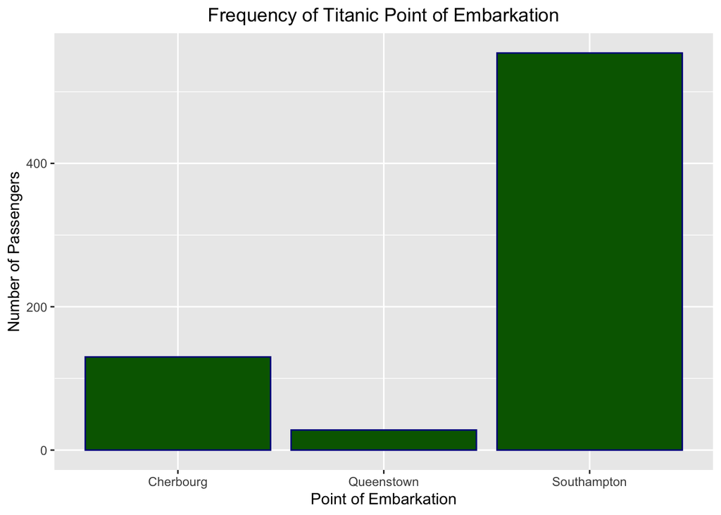

```r
library(tidyverse)
ggplot(data = titanic, aes(x = Embarked)) +
  geom_bar(fill = "darkgreen", color = "darkblue") +
  labs(title = "Frequency of Titanic Point of Embarkation",
       x = "Point of Embarkation", y = "Number of Passengers") +
  theme(plot.title = element_text(hjust = 0.5)) +
  #make more label x-axis labels on tick marks
  scale_x_discrete(labels=c("C" = "Cherbourg", "Q" = "Queenstown",
                              "S" = "Southampton"))
```

*Here we changed the `fill` and `color` arguments from what was given in the homework (pink and black). The `fill` argument is responsible for the inner color of the bars, whereas the `color` argument is responsible for the borders of each bar.*

*Note that we also used the `scale_x_discrete()` function within `ggplot` to change the labels of the x-axis tick marks. You weren’t required to do this, but it does make it easier to interpret the plot (especially for those who don’t know what C, Q, and S stand for). However, you should have gotten practice using a function like this for the last question on the homework (Problem 5E).*

4. (5pts) Using your graph from Part C, describe the distribution of the `Embarked` variable in 1-2 sentences. In particular: Which port did the most passengers embark on, and which port did the fewest passengers embark on? Be sure to write your description as if it were for someone who isn’t familiar with the data. **In your answer, be sure to use the actual port names, and not just “C”, “Q”, “S”.** In general, your descriptions of graphs should make sense to people who are not familiar with the actual dataset.

*From our graph in Part C, we see that the most common point of embarkation was Southampton; over half of Titanic passengers were from Southampton. The second most common was Cherbourg; the least common was Queenstown.*

5. (6pts) Now make a spine chart of the `Embarked` variable. Make sure to correctly label the axes, and include an appropriate title. In your spine chart, what are the widths of the bars proportional to (if anything)? What are the heights of the bars proportional to (if anything)? How is this different from the bar chart?

*Here is a spine chart of the `Embarked` variable:*

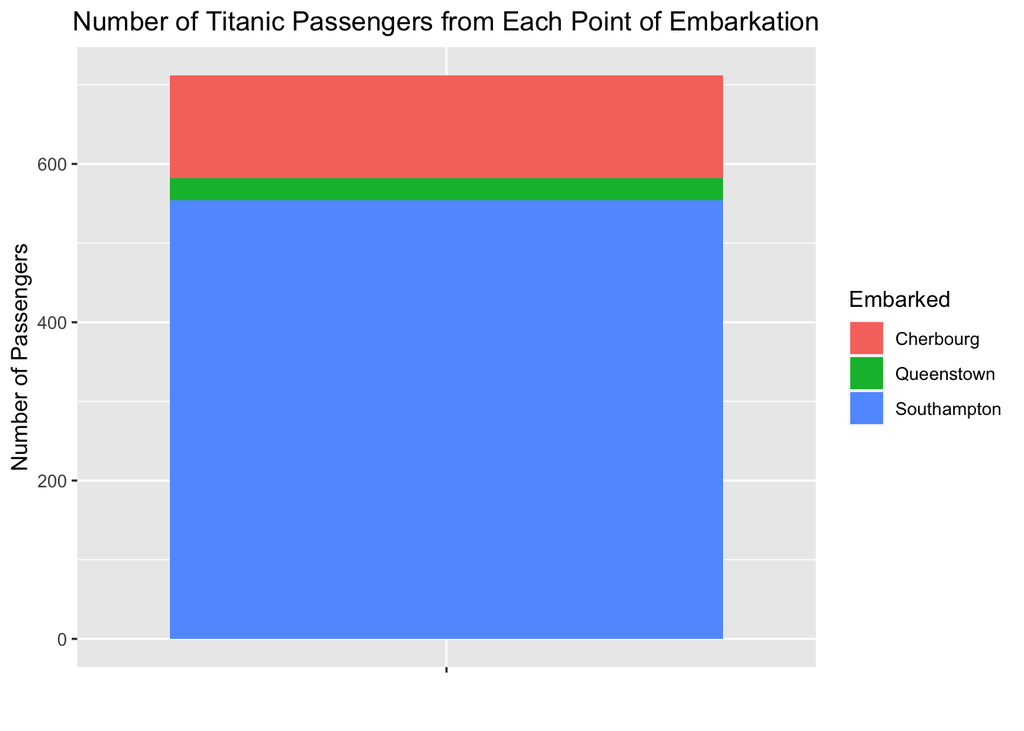

```r
ggplot(data = titanic) +
  geom_bar(aes(x = "", fill = Embarked)) +
  labs(title = "Number of Titanic Passengers from Each Point of Embarkation",
       x = "",
       y = "Number of Passengers",
       fill = "Point of Embarkation") +
  theme(plot.title = element_text(hjust = 0.5)) +
  #change the legend labels
  scale_fill_discrete(name = "Embarked", labels = c("Cherbourg","Queenstown","Southampton"))
```

*In a spine chart, the bars representing each value of the variable are stacked on top of each other. Each bar has the same width (i.e., it isn’t proportional to anything; or rather, it’s proportional to a constant). Meanwhile, the height of each bar is proportional to the frequency of the category it represents (in this case, point of embarkation). The difference between this and the bar chart is simply that the bars are stacked on top of each other, rather than placed side by side.*

6. (3pts) `ggplot()` allows us to easily flip the orientation of our graphs without changing much of the code. To do this, you simply have to add `+ coord_flip()` to your existing code. Do this in a separate code block for the spine chart from Part E, and discuss the differences in the two plots.

*Here is the same spine chart, but flipped:*

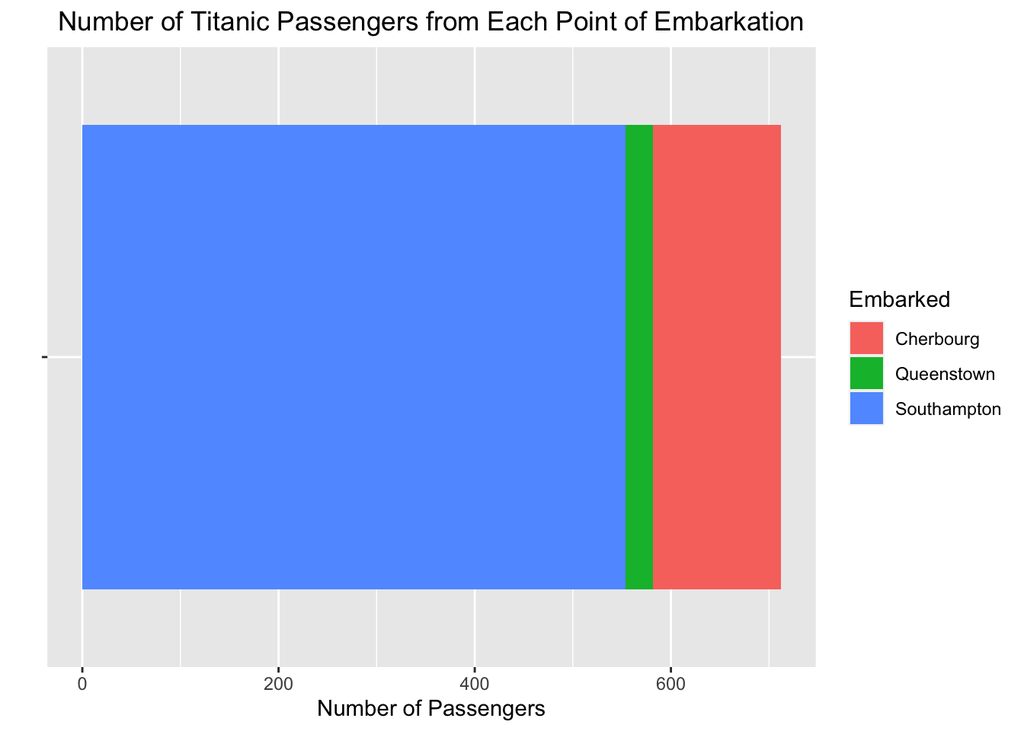

```r
ggplot(data = titanic) +
  geom_bar(aes(x = "", fill = Embarked)) +
  coord_flip() +
  labs(title = "Number of Titanic Passengers from Each Point of Embarkation",
       x = "",
       y = "Number of Passengers",
       fill = "Point of Embarkation") +
  theme(plot.title = element_text(hjust = 0.5)) +
  #change the legend labels
  scale_fill_discrete(name = "Embarked", labels = c("Cherbourg","Queenstown","Southampton"))
```

*When we flip the coordinates, the height of each subsection is now constant. The width of each subsection is proportional to the frequency of the corresponding category.*

7. (6pts) Now make a rose diagram of the `Embarked` variable. Be sure to correctly label the axes and include an appropriate title. In your rose diagram, what is the radius of each rose petal proportional to? What does the angle associated with each rose petal correspond to (if anything)? What is the area of each rose petal proportaional to?

*Here is a rose diagram of the `Embarked` variable:*

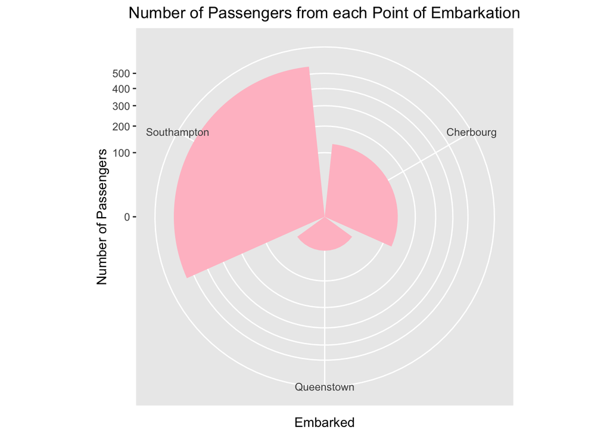

```r
ggplot(data = titanic, aes(x = Embarked)) +
  geom_bar(fill = "pink") +
  coord_polar() + scale_y_sqrt() +
  labs(title  = "Number of Passengers from each Point of Embarkation",
       x      = "",
       y      = "Number of Passengers",
       fill   = "Point of Embarkation") +
  theme(plot.title = element_text(hjust = 0.5)) +
  scale_x_discrete(name = "Embarked", labels = c("Cherbourg","Queenstown","Southampton"))
```

*In our rose diagram, the radius is proportional to the square root of the number of passengers (because we used `scale_y_sqrt()`). The angle is constant across categories (i.e., the angle is proportional to a constant). As a result, the area of each petal is proportional to the number of passengers (because the area is proportional to the square of the radius).*

*Note that if you did not use `scale_y_sqrt()`, this is what the rose diagram would look like:*

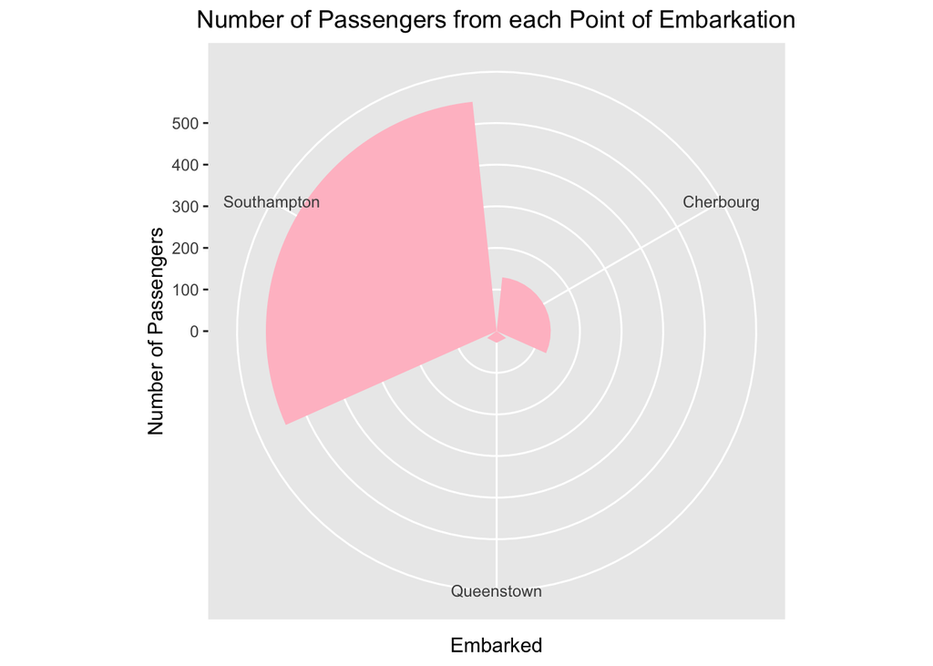

```r
ggplot(data = titanic, aes(x = Embarked)) +
  geom_bar(fill = "pink") +
  coord_polar() +
  labs(title  = "Number of Passengers from each Point of Embarkation",
       x      = "",
       y      = "Number of Passengers",
       fill   = "Point of Embarkation") +
  theme(plot.title = element_text(hjust = 0.5)) +
  scale_x_discrete(name = "Embarked", labels = c("Cherbourg","Queenstown","Southampton"))
```

*Yes, Queenstown was the least frequent point of embarkation, but now the infrequency of Queenstown is quadratically exaggerated (quadratically because the area is proportional to the square of the radius, and here the radius is proportional to the number of passengers). For example, from the data we can find that Queenstown is about 20 times less frequent than Southampton; however, in the above (incorrect) rose diagram, the area for Queenstown is approximately $20^2 = 400$ times smaller than the area for Southampton.*

# Problem 4: Visualizing really old data with modern ggplot2 (20 points)

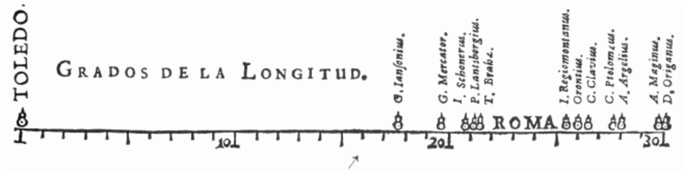

Let’s explore the data from the really early graphic examining the estimated Longitude distance between Toledo and Rome that was visualized in 1644 by Langren. Install the `HistData` package and the `forcats` package. Then, load the `Langren1644` dataset into `R` by typing `data(Langren1644)`. See below for some example code (which also corrects a naming error in the `Langren1644` dataset). Before starting this problem, be sure to uncomment the example code below. Note that you’ll have to make sure the three packages at the beginning of the code block are installed for the code to properly run.

```r
#make sure these packages/libraries are installed
library(tidyverse)
library(HistData)
library(forcats)

#load the data
data(Langren1644)

#Correcting the slight misspelling of "Italy " to "Italy" in the Langren1644 data.
#The code collapses the two levels "Italy" and "Italy " of the factor variable
Langren1644 <- Langren1644 %>% mutate(Country = fct_recode(Country,"Italy" = "Italy "))
```

1. (6 points) The plots you made for the Titanic data in Problem 3 visualize a single variable; now we will visualize multiple variables within a single graph. We’ll discuss the statistical nuances of graphs with multiple variables later on—the purpose of this problem is just to further explore the `ggplot()` function in more depth.

In this part, we’ll create a [scatterplot](https://en.wikipedia.org/wiki/Scatter_plot); I’m assuming most of you are familiar with such a plot, but we’ll talk about it in depth later in the course. For now, **the goal of this problem is to make a scatterplot where**:

- `Longitude` is on the x-axis
- `Year` is on the y-axis
- The points in the scatterplot are colored by `Country`

**After you’ve made your scatterplot, write 1-2 sentences describing what the scatterplot is showing.** You may have to look at the help documentation at `help(Langren1644)` to understand what the variables in your scatterplot are.

*First, here is the desired scatterplot:*

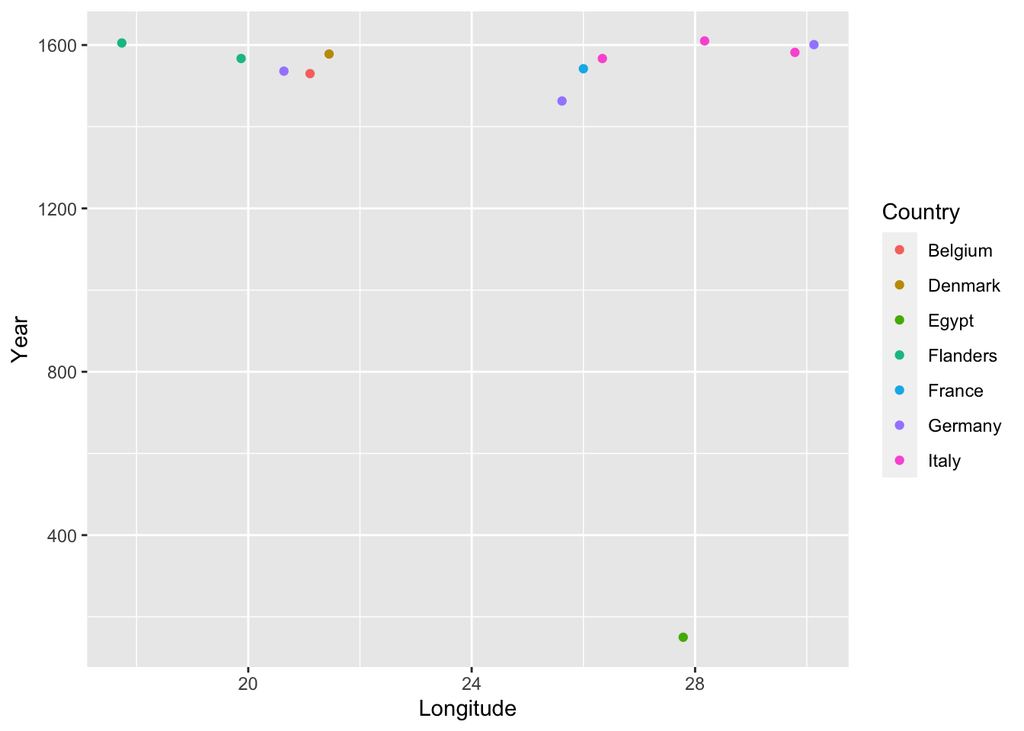

```r
ggplot(data = Langren1644, aes(x = Longitude, y = Year)) +
  geom_point(aes(color = Country))
```

*In this graph, the x-axis refers to the estimated value of the longitude distance between Toledo and Rome, and the y-axis refers to the year that estimate was made. Furthermore, the color denotes the country associated with the estimate.*

2. (6 points) Note that even though a scatterplot is considered a “two dimensional” visual, your scatterplot in Part A should have three variables (longitude, year, and country), and thus it is sort of like a “3D plot.” Now we’re going to make a “4D plot.” **The goal of this problem is to make a scatterplot where**:
- `Longitude` is on the x-axis
- `Year` is on the y-axis
- The points in the scatterplot are colored by `Country`
- The shape of the points correspond to the **source** of longitudinal measurement.
- There’s a vertical line indicating the true longitudinal distance between Toledo and Rome.

To do this problem, first copy-and-paste the code you wrote for Part A. After you do that, already the first three bullet points are done! Meanwhile, to change the shape of the points, mimic what you did with the `color` parameter in `aes`, but this time do `aes(color = ..., shape = ...)`, where `color` and `shape` are appropriately specified. Then, to add a vertical line, first use Google or `help(Langren1644)` to figure out the true longitudinal distance between Toledo and Rome. Then, use `+ geom_vline(aes(xintercept = _))` right after your `geom_point(...)` code, where you should replace `_` with the longitudinal distance between Toledo and Rome.

**For this part, all you need to do is write the code to produce the desired scatterplot (as well as display the scatterplot, which your code should do automatically).**

*Here is the desired scatterplot:*

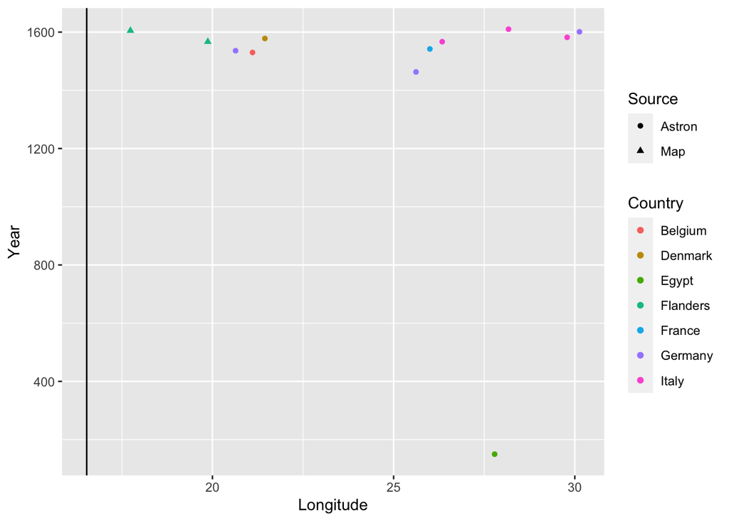

```r
ggplot(data = Langren1644, aes(x = Longitude, y = Year)) +
  geom_point(aes(color = Country, shape = Source)) +
  geom_vline(aes(xintercept = 16.53))
```

3. (8 points) Now we’re going to make one more scatterplot. First, copy-and-paste your code from the previous part (Part B) and place it here. Then, after your `geom_point(...)` code, use `+ geom_text(aes(label = Name), hjust = -0.05, vjust = -0.05, angle = -90)`. This should add text next to each point; revisit `help(Langren1644)` to understand what exactly this text is. It’s okay if some of the text isn’t displayed in the plot (particularly the bottom part of the plot).

Here is the desired scatterplot:

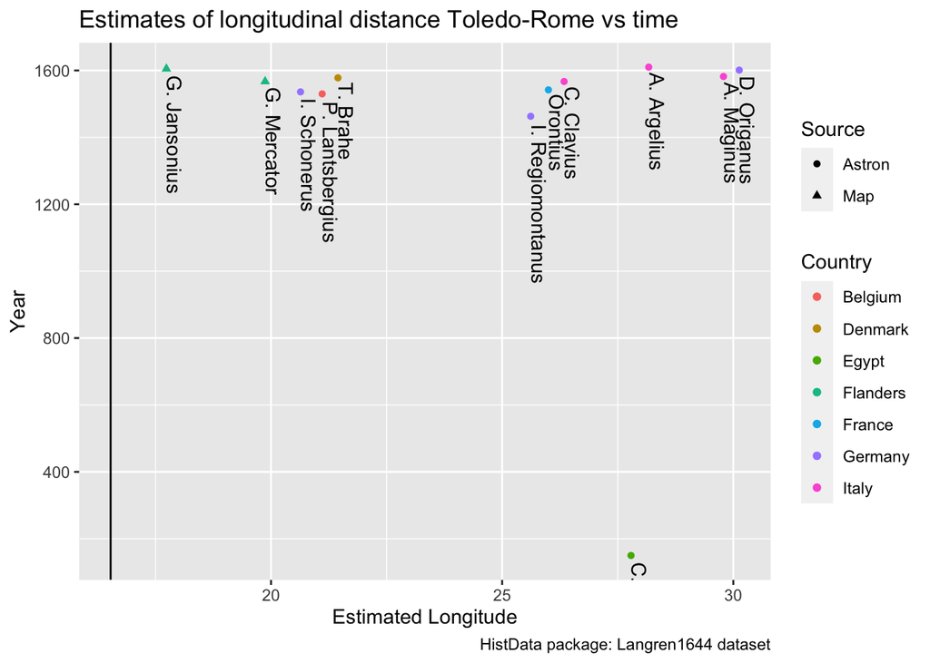

```r
ggplot(data = Langren1644, aes(x = Longitude, y = Year)) +
  geom_point(aes(color = Country, shape = Source)) +
  geom_text(aes(label = Name), hjust = -0.05, vjust = -0.05, angle = -90) +
  geom_vline(aes(xintercept = 16.53)) +
  labs(
    title = "Estimates of longitudinal distance Toledo-Rome vs time",
    x = "Estimated Longitude",
    caption = "HistData package: Langren1644 dataset"
  )
```

After you’ve made your plot, add a title that (briefly) describes the plot. Then, answer the following questions:

- Who gave the most accurate estimate?

*G. Jansonius gave the most accurate estimate.*

- Which country gave the most accurate estimates?

*The most accurate estimates were made by individuals from Flanders.*

- Is the oldest estimate the worst?

*The oldest estimate is not the worst, as there were 3 later estimates, made in Italy and Germany, that are worse than the oldest estimate.*

- Which source seems more accurate?

*The map seems to be more accurate, since the two most accurate estimates used maps.*

# Problem 5: Variable Types (25 points)

In this question, we will consider a toy dataset of 100 people with the following variables:

- `hair`: The hair color of each person (black, brown, blonde, red, or other).
- `age`: Number of years this person has been alive
- `income`: Measured in US dollars.
- `children`: Number of children this person has.
- `opinion`: Response to the statement: “There shouldn’t be any 36-315 homework.” Here, 3 = agree, 2 = not sure, 1 = disagree.

The toy dataset can be viewed [here](https://raw.githubusercontent.com/zjbranson/315Fall2021/master/hw1DataTypes.csv).

1. (5pts) Below is some code to read in the dataset. For each of the five variables, write down:
1. Whether the variable is categorical (nominal), categorical (ordinal), quantitative (discrete), or quantitative (continuous).
2. The class of the variable according to `R`. (Hint: You can use the `class()` function to figure this out, as shown for the `hair` variable below. We can see that the class of the `hair` variable is “character”, so already you have one of the answers!) (Note: For some versions of `R`, the class for `hair` may appear as `"factor"` instead of `"character"`, which is fine.)

**You do not have to turn in any code for this question.** Just answer the two above prompts for each of the five variables.

*Below are the variable types and `R` class for each variable in the toy dataset:*

- *`hair`: Categorical (nominal) and “character”*
- *`age`: Quantitative (continuous) and “integer”. Here we wrote “continuous” because it’s possible for someone to be, e.g., 40.5 years old. However, there are only whole numbers in the dataset, so it’s fine fi you wrote “discrete” instead.*
- *`income`: Quantitative (continuous) and “numeric”.*
- *`children`: Quantitative (discrete) and “integer”.*
- *`opinion`: Categorical (ordinal) and “integer”.*

*The code below (not necessary for full credit on the assignment) shows you how you can look at this dataset and check the class of each variable. These are standard preliminary steps you should take for understanding any dataset.*

```r
#reading in the data
data <- read.csv("https://raw.githubusercontent.com/zjbranson/315Fall2021/master/hw1DataTypes.csv")
#names of the variables
names(data)
```

```
## [1] "hair"     "age"      "income"   "children" "opinion"
```

```r
#classes of the variables
class(data$hair)
```

```
## [1] "character"
```

```r
class(data$age)
```

```
## [1] "integer"
```

```r
class(data$income)
```

```
## [1] "numeric"
```

```r
class(data$children)
```

```
## [1] "integer"
```

```r
class(data$opinion)
```

```
## [1] "integer"
```

2. (5pts) In `R`, quantitative variables should usually have class `"numeric"` or `"integer"`, while categorical variables should usually have class `"factor"` or `"character"`. Given this and your answer in Part A, which variables in the dataset have unintuitive classes? Explain your answer in 1-2 sentences.

*The variable `opinion` has an unintuitive class; it has class “integer” (suggesting that it is a quantitative variable), but in fact it is a categorical variable. It is true that `opinion` is an ordinal variable, but nonetheless the “integer” class gives the false impression that `opinion` is quantitative when it is not.*

3. (5pts) For this part, use `ggplot()` to make a scatterplot where:
- `age` is on the x-axis
- `income` is on the y-axis
- The points are colored by `opinion`

You should be able to use code very similar to Question 4 to do this. Your scatterplot should have a color legend for the `opinion` variable on the right-hand side. From this legend, how many possible values does there appear to be for the `opinion` variable?

*Here is the desired scatterplot:*

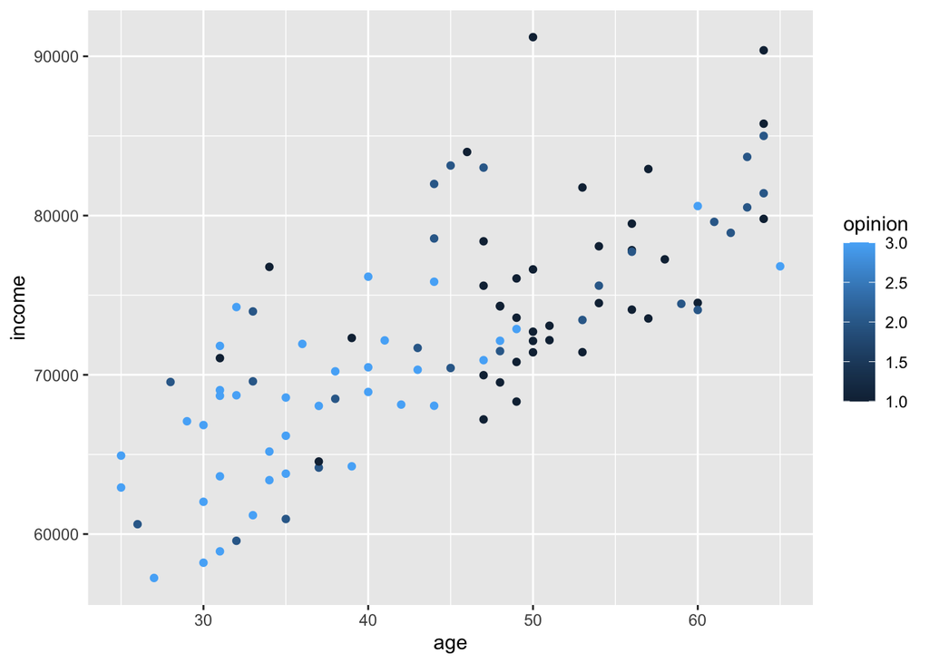

```r
library(tidyverse)
ggplot(data = data, aes(x = age, y = income)) +
  geom_point(aes(color = opinion))
```

*From this legend, it seems like there are at least five possible values for the `opinion` variable: 1.0, 1.5, 2.0, 2.5, and 3.0. In fact, it suggests that there are an infinite number of values (any number between 1 and 3).*

4. (5pts) It’s often helpful to change the class of variables using functions like `as.numeric()` and `as.factor()`. Luckily, `ggplot()` makes it very easy to convert variables to factors: Simply place `factor()` “around” a variable name within `ggplot()`.

Now make the same scatterplot from Part C, but with `opinion` converted to a factor by using `factor(opinion)`.

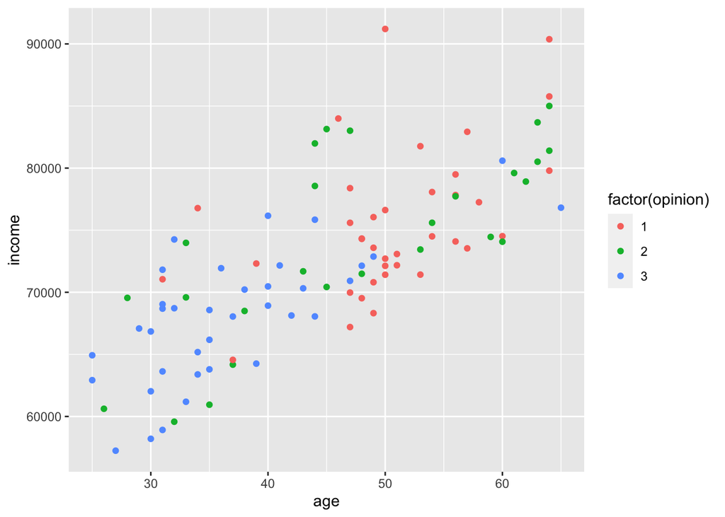

```r
ggplot(data = data, aes(x = age, y = income)) +
  geom_point(aes(color = factor(opinion)))
```

Your scatterplot should still have a color legend for the `opinion` variable on the right-hand side. From this legend, how many possible values does there appear to be for the `opinion` variable? Which scatterplot do you think is more intuitive - the one in this part, or the one in Part C? Explain your answer in 1-2 sentences.

*From this legend, it seems like there are only three possible values for the `opinion` variable: 1, 2, or 3. This scatterplot is more intuitive than the previous one, because indeed 1, 2, or 3 are the only possible values for the `opinion` variable.*

5. (5pts) The color legend in your Part D probably looks a bit ugly, in the sense that people not familiar with this dataset may have trouble understanding it. For this part, first copy-and-paste your code from Part D and place it here. Then, to make the color legend more understandable, make the following changes to your plot:
- Notice that your color legend displays “factor(opinion)”, which doesn’t look too great. Change this to “Opinion” instead of “factor(opinion)”.
- Notice that your color legend just has the labels 1, 2, and 3, which readers not familiar with this dataset won’t understand. Change these labels to something more meaningful based on the definition of `opinion` given at the beginning of this problem.

**Hint**: For this problem I thought about just expecting you to Google how to do this and figure it out yourself, but after some reflection I thought that was too mean, especially because it’s the beginning of the semester. After I Googled “change legend labels in r”, the first result was [this page](https://www.datanovia.com/en/blog/ggplot-legend-title-position-and-labels/), which I use a lot for `ggplot()` legends. See the “Rename legend labels and change the order of items” section of that page. Since you specified `color` in your plot, you’ll need to use the `scale_color_discrete()` function.

*Below is the desired scatterplot. Note that we used the `scale_color_discrete()` function to change the legend labels for this plot. In general, there are many functions in the form of `scale_x_discrete()`, and here we use `scale_color_discrete()` because we want to change the labels for the `color` argument that we specified in `aes()`.*

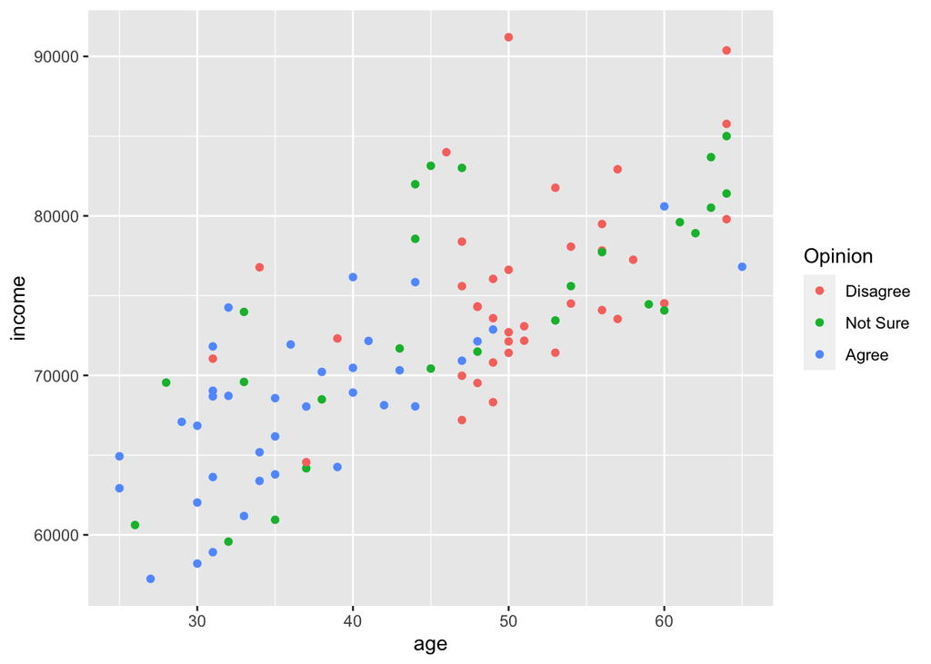

```r
ggplot(data = data, aes(x = age, y = income)) +
  geom_point(aes(color = factor(opinion))) +
  scale_color_discrete(name = "Opinion",
    labels = c("Disagree", "Not Sure", "Agree"))
```

*More generally, the point of this whole problem was to demonstrate that R can give unintuitive graphs and analyses if variables aren’t appropriately classified. For this reason, it’s good practice to check the class of each variable before you start making graphs and analyses. Variables like `opinion` (where numbers are used to denote categories) are very common, so you should especially be on the lookout for those! As we will discuss later in the course, standard statistical analyses will give you inappropriate/incorrect results if you just plugged in `opinion` as is before recoding it as a categorical variable using a function like `factor()`.*